# InitialAnalysis_RPXErosionModeling

Omprakash Samudrala

April 17, 2018

## Initial Analysis

Dataset for the analysis titled **ModelDataSet** was added to the data folder of the project

Data Sets contains 6 parameters (columns) - 5 of which are predictors (Mean Process Flow, Std Deviation Process Flow, Mean Motive Flow, Std Dev Motive Flow, number of RPXs running) and 1 response variable (Erosion Potential)

Objectives

- Read data, randomize and split it into 3 sets - **training** data set, **validation** data set and **test** data set
- Plot the predictors and response variable
- Try a naive model - mean of the response variable across the training data set
- Determine how well does the model do to predict the response - mean absolute deviation of the response variable from actual response
- Figure out if the success metric is achieved (mean absolute deviation < 0.05)

```
## [1] "C:/Users/ompra/Documents/UCBCourses/Datascience/project"
```

```
## 'data.frame':    9514 obs. of  6 variables:
##  $ MeanProcFlow    : num  210 350 175 175 262 ...
##  $ StDevProcFlow   : num  7.76 15.98 7.12 7.12 10.79 ...
##  $ MeanMotFlow     : num  252 420 210 210 315 210 420 315 210 315 ...
##  $ StDevMotFlow    : num  11.29 36.17 13.56 18.8 4.88 ...
##  $ numRPX          : num  10 6 12 12 8 12 6 8 12 8 ...
##  $ ErosionPotential: num  0.3 0.5 0.25 0.25 0.25 ...
```

```
##   MeanProcFlow   StDevProcFlow     MeanMotFlow   StDevMotFlow
##  Min.   :175.0   Min.   : 4.460   Min.   :210   Min.   : 3.611
##  1st Qu.:175.0   1st Qu.: 7.125   1st Qu.:210   1st Qu.: 4.678
##  Median :210.0   Median : 8.137   Median :252   Median : 8.810
##  Mean   :233.3   Mean   : 9.204   Mean   :280   Mean   :11.002
##  3rd Qu.:262.5   3rd Qu.:10.592   3rd Qu.:315   3rd Qu.:14.939
##  Max.   :350.0   Max.   :20.285   Max.   :420   Max.   :89.885
##      numRPX       ErosionPotential
##  Min.   : 6.000   Min.   :0.0000
##  1st Qu.: 8.000   1st Qu.:0.2500
##  Median :10.000   Median :0.3000
##  Mean   : 9.557   Mean   :0.3050
##  3rd Qu.:12.000   3rd Qu.:0.3750
##  Max.   :12.000   Max.   :0.6667
```

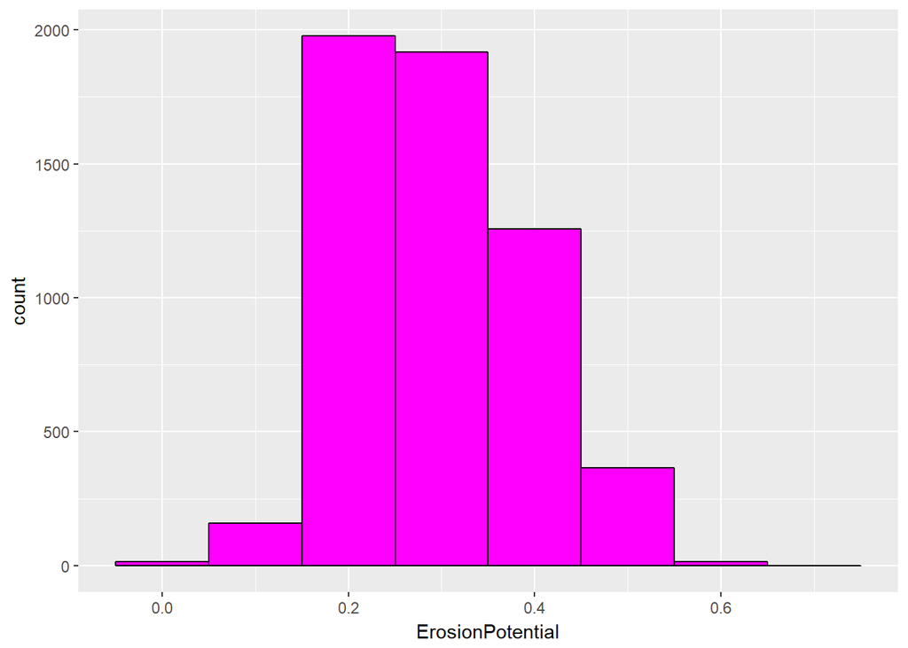

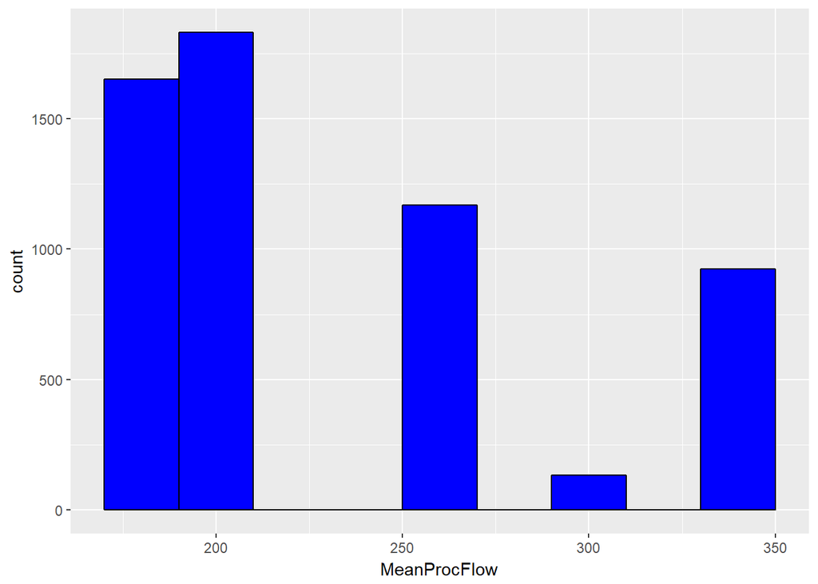

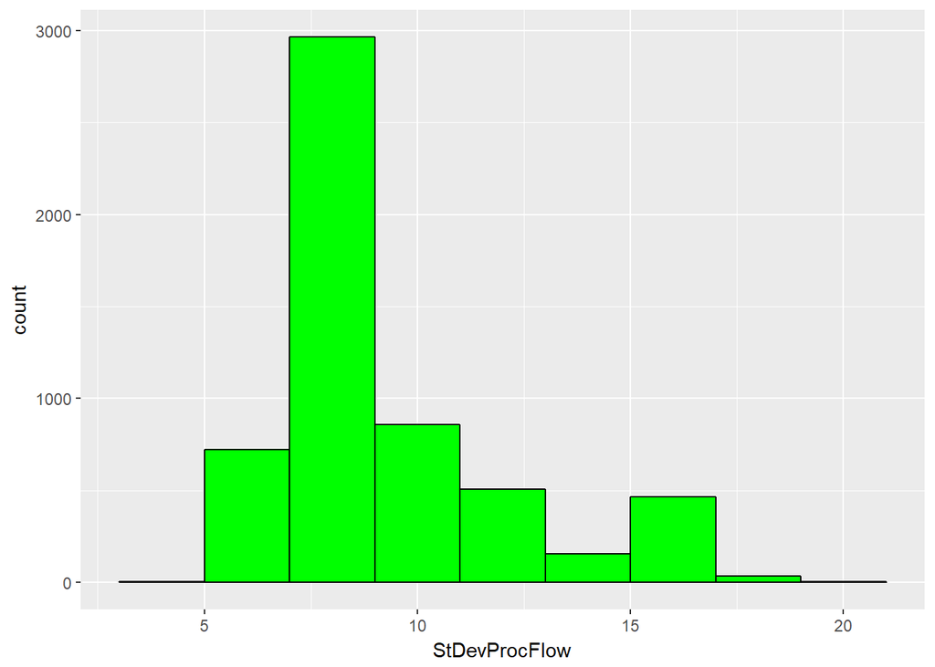

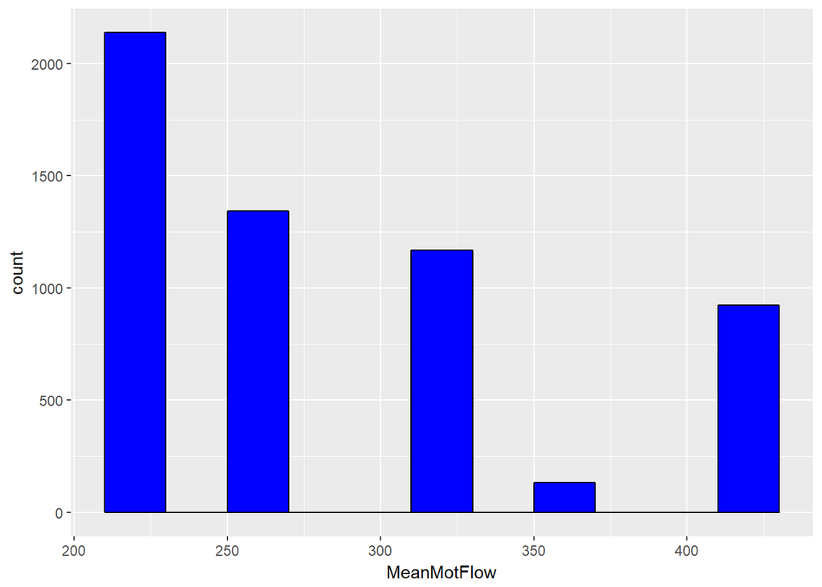

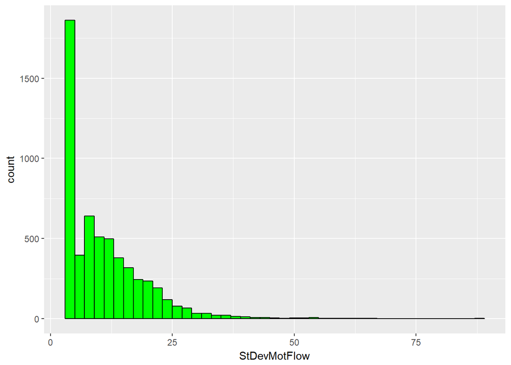

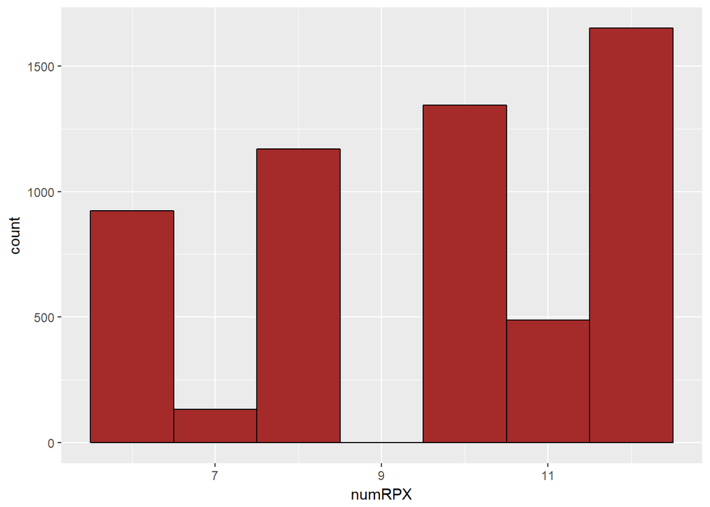

```
## [1] 0.07504859
```

The mean absolute deviation obtained from the naive model was **0.0750486**. Hence it does not meet the success metric of **< 0.05**

On to other models …..

The next set of plots show how the actual response variable and the naive response prediction with respect to each of the predictors.

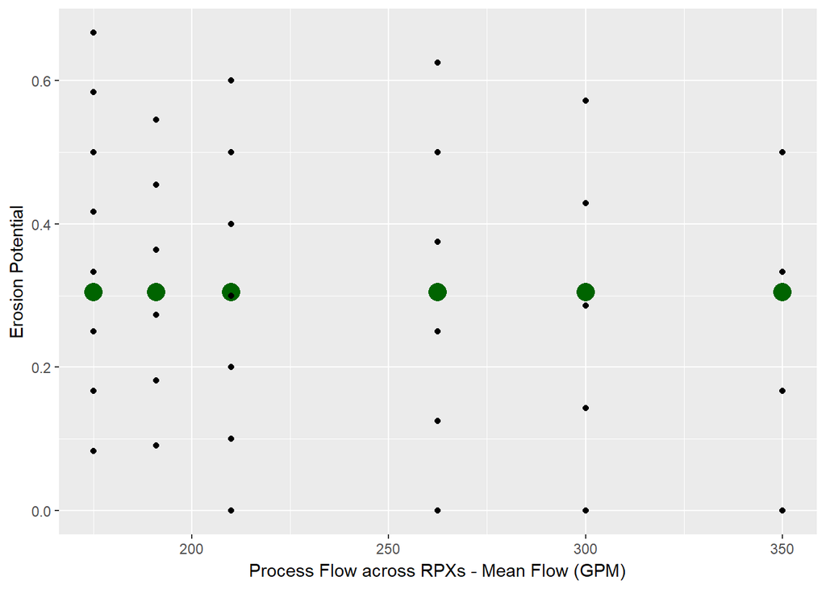

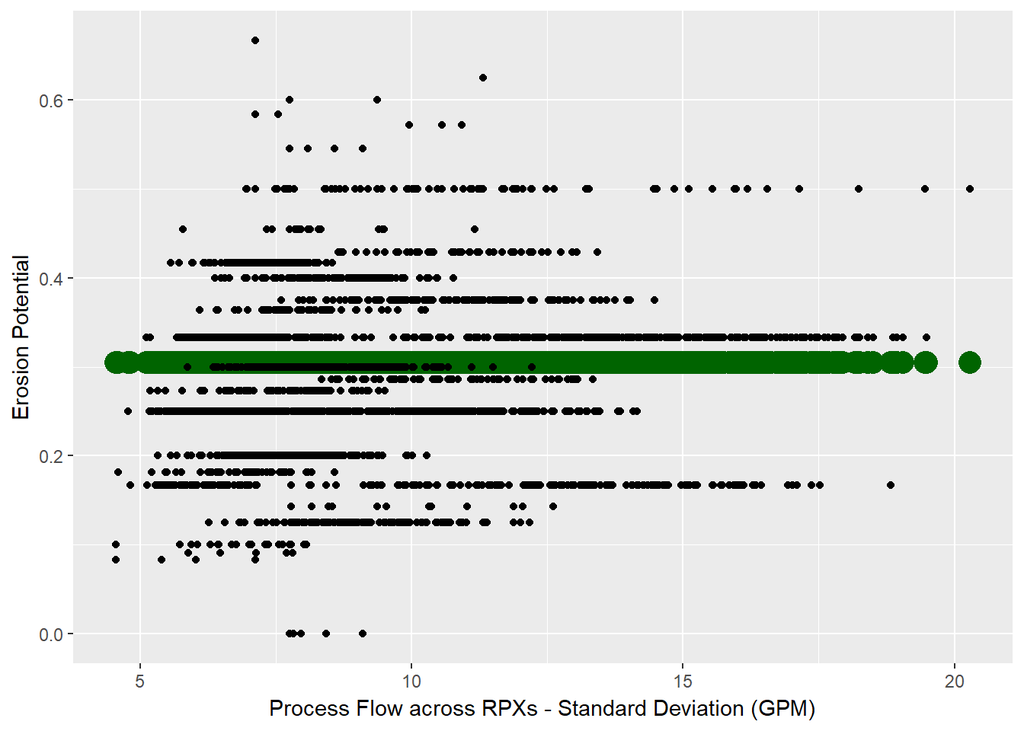

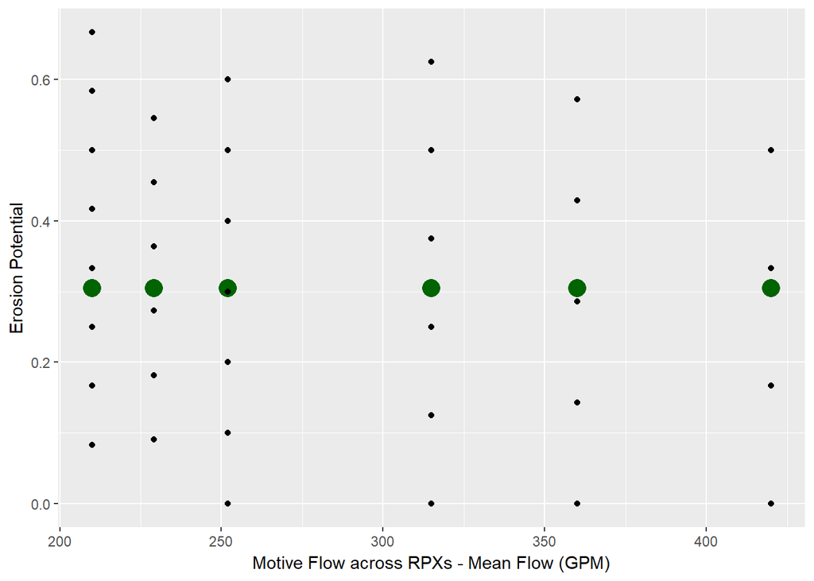

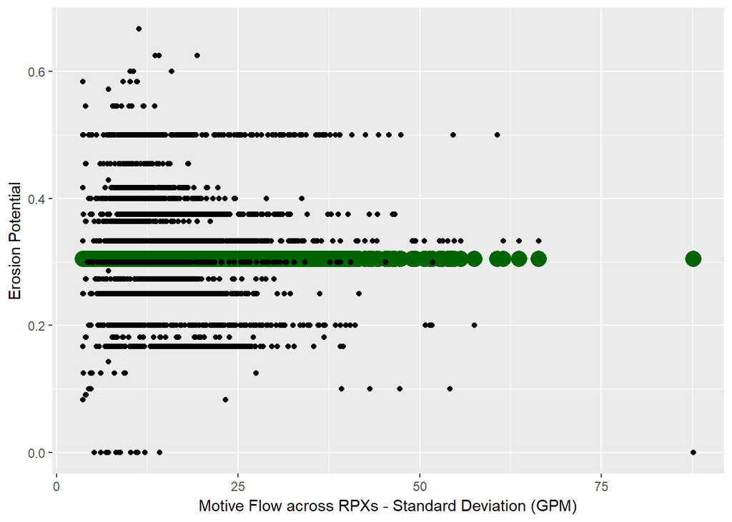

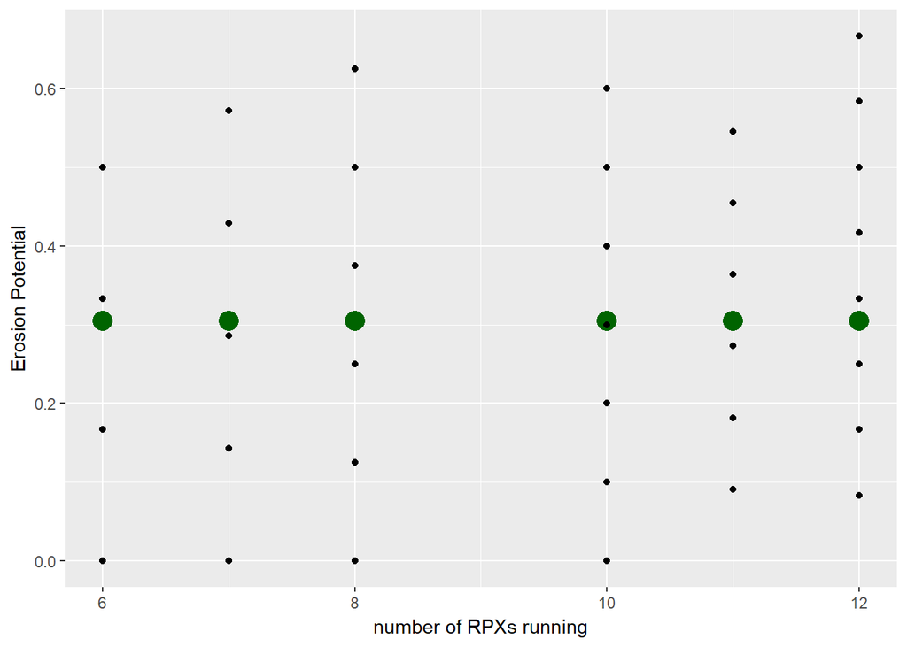